# 23_determinant_A

## 23_determinant_A

#### Question

1. There is actually a shortcut to finding the area of a parallelogram like the one shown below.

   $$A=|x_1y_2-x_2y_1|$$

   With that in mind, find the area of the parallelogram shown below, where each small grey square has an area of 1.

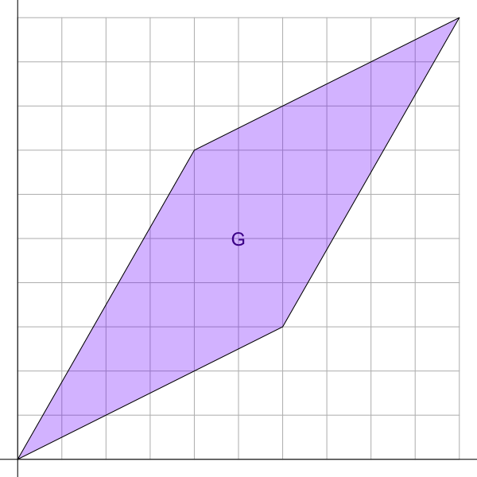

   $$G=~?$$

#### Question

2. There is actually a shortcut to finding the area of a parallelogram like the one shown below.

   $$A=|x_1y_2-x_2y_1|$$

   With that in mind, find the area of the parallelogram shown below, where each small grey square has an area of 1.

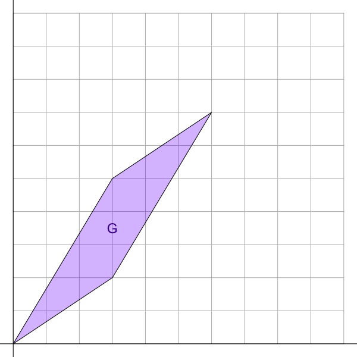

   $$G=~?$$

#### Question

3. There is actually a shortcut to finding the area of a parallelogram like the one shown below.

   $$A=|x_1y_2-x_2y_1|$$

   With that in mind, find the area of the parallelogram shown below, where each small grey square has an area of 1.

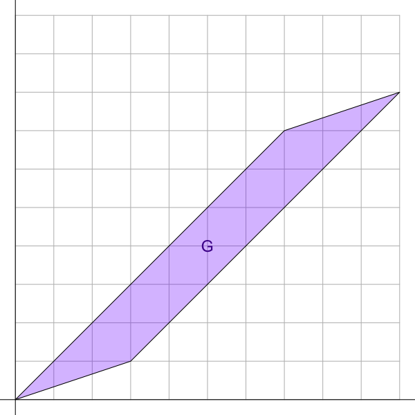

   $$G=~?$$

#### Question

4. There is actually a shortcut to finding the area of a parallelogram like the one shown below.

   $$A=|x_1y_2-x_2y_1|$$

   With that in mind, find the area of the parallelogram shown below, where each small grey square has an area of 1.

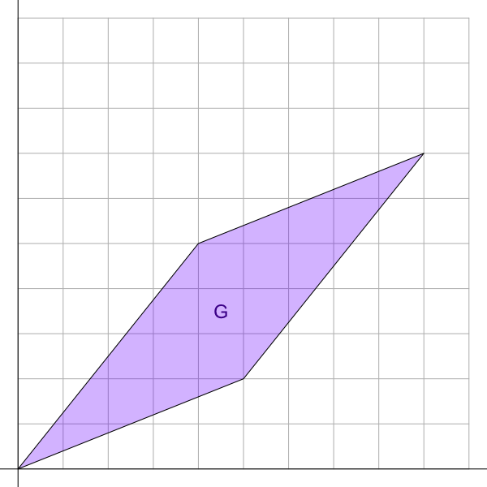

   $$G=~?$$

#### Question

5. There is actually a shortcut to finding the area of a parallelogram like the one shown below.

   $$A=|x_1y_2-x_2y_1|$$

   With that in mind, find the area of the parallelogram shown below, where each small grey square has an area of 1.

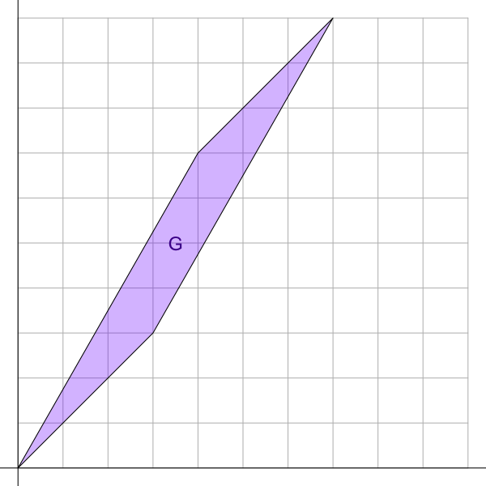

   $$G=~?$$

#### Question

6. There is actually a shortcut to finding the area of a parallelogram like the one shown below.

   $$A=|x_1y_2-x_2y_1|$$

   With that in mind, find the area of the parallelogram shown below, where each small grey square has an area of 1.

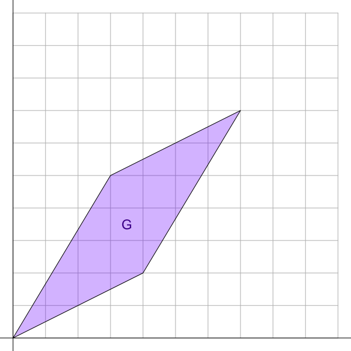

   $$G=~?$$

#### Question

7. There is actually a shortcut to finding the area of a parallelogram like the one shown below.

   $$A=|x_1y_2-x_2y_1|$$

   With that in mind, find the area of the parallelogram shown below, where each small grey square has an area of 1.

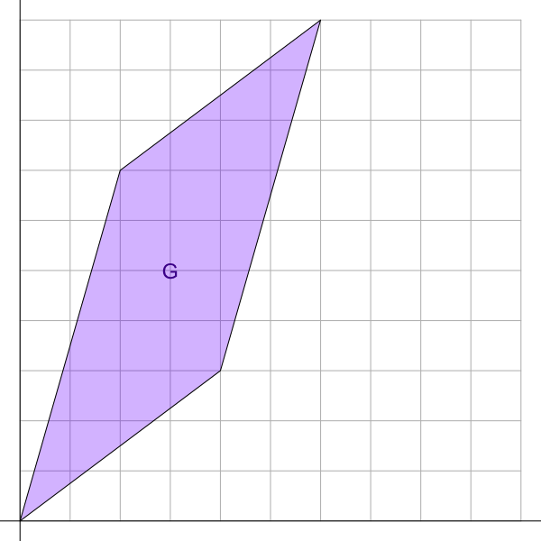

   $$G=~?$$

#### Question

8. There is actually a shortcut to finding the area of a parallelogram like the one shown below.

   $$A=|x_1y_2-x_2y_1|$$

   With that in mind, find the area of the parallelogram shown below, where each small grey square has an area of 1.

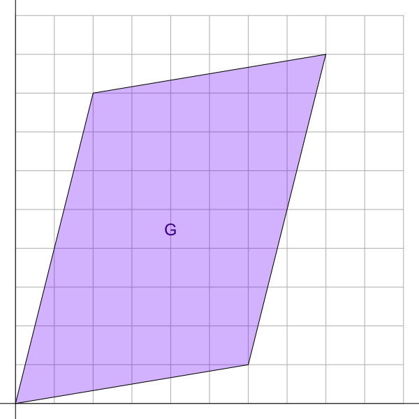

   $$G=~?$$